# IST 707 HW1- Association Rule Mining

-Mihir Deshpande

February 10, 2019

#### This Homework assigments deals with mining interesting rules to predict income. ‘AdultUCI’ dataset from ‘arules’ package in used for the analysis.Steps involved in the process are:-

1.Cleaning the dataset and getting it in the desired format which is suitable for the apiori method.

```
-Dealing with missing values- A dual approach was used to deal with missing values.Income variable,which is the variable of interest has almost 1/3rd values missing.Imputing this variable may result in non-credible results.Therefore rows with missing values in the income variable were deleted.Rest of the variables with missing values were imputed using K-NN imputation using DMwR package

-Discretization of numeric variable with discrete classes.This is needed as the apriori method does not work with numeric values.Special care was taken to deal with 'captial-gain' and 'capital-loss' variables are they have majority of values as zero

-Qualitative variables with many levels were collapsed into fewer levels. This was done because apriori association rule method does not work well with categorical variable with many levels
```

2. Visual Data exploration- Using tidyverse and ggplot2, barplots to analyse income against different variables were plotted. Insights generated were reported.
3. Association Rule mining using apriori method- The record dataset was converted into a transactional dataset to perform the analysis.Apiori method with default values used first and then experimented with different parameter values to generate top rules. Rules to predict income mined.Visuaisation of the mined rules was done using ‘plot’ function and arulesViz package. 4.Shiny Application to access and visualise top rules based on user given parameters created and deployed on shinyapps.io . Link to the app is provided below.

**Load required packages**:-

```r
library(arules)
```

```r
library(arulesViz)
library(ggplot2)
library(tidyverse)
```

**Load AdultUCI dataset form ‘arules’ package:-**

```r
data("AdultUCI")
adultDf<-AdultUCI
```

**Basic Data Exploration**

```r
summary(adultDf)
```

```
##       age                   workclass         fnlwgt
##  Min.   :17.00   Private         :33906   Min.   :  12285
##  1st Qu.:28.00   Self-emp-not-inc: 3862   1st Qu.: 117551
##  Median :37.00   Local-gov       : 3136   Median : 178145
##  Mean   :38.64   State-gov       : 1981   Mean   : 189664
##  3rd Qu.:48.00   Self-emp-inc    : 1695   3rd Qu.: 237642
##  Max.   :90.00   (Other)         : 1463   Max.   :1490400
##                  NA's            : 2799
##         education     education-num                 marital-status
##  HS-grad     :15784   Min.   : 1.00   Divorced             : 6633
##  Some-college:10878   1st Qu.: 9.00   Married-AF-spouse    :   37
##  Bachelors   : 8025   Median :10.00   Married-civ-spouse   :22379
##  Masters     : 2657   Mean   :10.08   Married-spouse-absent:  628
##  Assoc-voc   : 2061   3rd Qu.:12.00   Never-married        :16117
##  11th        : 1812   Max.   :16.00   Separated            : 1530
##  (Other)     : 7625                   Widowed              : 1518
##            occupation            relationship                   race
##  Prof-specialty : 6172   Husband       :19716   Amer-Indian-Eskimo:  470
##  Craft-repair   : 6112   Not-in-family :12583   Asian-Pac-Islander: 1519
##  Exec-managerial: 6086   Other-relative: 1506   Black             : 4685
##  Adm-clerical   : 5611   Own-child     : 7581   Other             :  406
##  Sales          : 5504   Unmarried     : 5125   White             :41762
##  (Other)        :16548   Wife          : 2331
##  NA's           : 2809
##      sex         capital-gain    capital-loss    hours-per-week
##  Female:16192   Min.   :    0   Min.   :   0.0   Min.   : 1.00
##  Male  :32650   1st Qu.:    0   1st Qu.:   0.0   1st Qu.:40.00
##                 Median :    0   Median :   0.0   Median :40.00
##                 Mean   : 1079   Mean   :  87.5   Mean   :40.42
##                 3rd Qu.:    0   3rd Qu.:   0.0   3rd Qu.:45.00
##                 Max.   :99999   Max.   :4356.0   Max.   :99.00
##
##        native-country    income
##  United-States:43832   small:24720
##  Mexico       :  951   large: 7841
##  Philippines  :  295   NA's :16281
##  Germany      :  206
##  Puerto-Rico  :  184
##  (Other)      : 2517
##  NA's         :  857
```

```r
str(adultDf)
```

```
## 'data.frame':    48842 obs. of  15 variables:
##  $ age           : int  39 50 38 53 28 37 49 52 31 42 ...
##  $ workclass     : Factor w/ 8 levels "Federal-gov",..: 7 6 4 4 4 4 4 6 4 4 ...
##  $ fnlwgt        : int  77516 83311 215646 234721 338409 284582 160187 209642 45781 159449 ...
##  $ education     : Ord.factor w/ 16 levels "Preschool"<"1st-4th"<..: 14 14 9 7 14 15 5 9 15 14 ...
##  $ education-num : int  13 13 9 7 13 14 5 9 14 13 ...
##  $ marital-status: Factor w/ 7 levels "Divorced","Married-AF-spouse",..: 5 3 1 3 3 3 4 3 5 3 ...
##  $ occupation    : Factor w/ 14 levels "Adm-clerical",..: 1 4 6 6 10 4 8 4 10 4 ...
##  $ relationship  : Factor w/ 6 levels "Husband","Not-in-family",..: 2 1 2 1 6 6 2 1 2 1 ...
##  $ race          : Factor w/ 5 levels "Amer-Indian-Eskimo",..: 5 5 5 3 3 5 3 5 5 5 ...
##  $ sex           : Factor w/ 2 levels "Female","Male": 2 2 2 2 1 1 1 2 1 2 ...
##  $ capital-gain  : int  2174 0 0 0 0 0 0 0 14084 5178 ...
##  $ capital-loss  : int  0 0 0 0 0 0 0 0 0 0 ...
##  $ hours-per-week: int  40 13 40 40 40 40 16 45 50 40 ...
##  $ native-country: Factor w/ 41 levels "Cambodia","Canada",..: 39 39 39 39 5 39 23 39 39 39 ...
##  $ income        : Ord.factor w/ 2 levels "small"<"large": 1 1 1 1 1 1 1 2 2 2 ...
```

#### Data Cleaning:

**Droping unwanted variables-education and education num provide the same information.Dropped education num.:-**

```r
adultDf<-adultDf[,-which(names(adultDf) %in% "education-num")]
```

**Check for Missing Values:-**

```r
sapply(adultDf, function(x) sum(is.na(x)))
```

```
##            age      workclass         fnlwgt      education marital-status
##              0           2799              0              0              0
##     occupation   relationship           race            sex   capital-gain
##           2809              0              0              0              0
##   capital-loss hours-per-week native-country         income
##              0              0            857          16281
```

**Dropping rows with missing values in the income variable:-**

```r
adultDf<-adultDf[!(is.na(adultDf$income)),]
```

**Missing Values- Used knnImputation function from DMwR package to impute missing values using Knn alogorithm:-**

```r
library(DMwR)
adultDf<-knnImputation(adultDf)
detach(package:DMwR)
```

**Check for missing values:-**

```r
sum(is.na(adultDf))
```

```
## [1] 0
```

**Dicretization:-**

*Dicretizing the age variable into low,medium and high :-*

```r
adultDf$age_grp <- discretize(adultDf$age, method = "frequency", breaks = 3,
                               labels = c("low", "medium", "high"), order = T)
```

*Dicretizing the fnl-wgt variable into small,medium and large:-*

```r
adultDf$fnlwgt<-discretize(adultDf$fnlwgt,method = "frequency",breaks=3,labels = c("small","medium","large"),order=T)
```

*Discretizing ‘hours-per-week’ variable using “cluster” method of discretize function which uses clustering alogorithm to achieve dicretization.evels used are low,medium,high and very high:-*

```r
adultDf$`hours-per-week`<-discretize(adultDf$`hours-per-week`,method = "cluster",breaks=4,labels=c("low","medium","high","very-high"),order=T)
#For Capital gain and capital loss variables, most frequent values are 0.Function used to achieve discretization is cut() and breaks selected accordingly
```

*Discretization for ‘capital-gain’ into levels Zero,Below_10000 and Above_10000:-*

```r
adultDf$capital_gain<-cut(adultDf$`capital-gain`,c(-Inf,0,10000,99999),labels = c("Zero","Below_10000","Above_10000"))
```

*Discretization for ‘capital-loss’ into levels Zero,Below_2000 and Above_2000:-*

```r
adultDf$capital_loss<-cut(adultDf$`capital-loss`,c(-Inf,0,2000,Inf),labels=c("Zero","Below_2000","Above_2000"))
```

**Colapsing multi-level categorical variables:-**

```r
list_countries<-levels(adultDf$`native-country`)
levels(adultDf$`native-country`)<-list("United Stated"=list_countries[39],"Other"=list_countries[-39])

list_occupation<-levels(adultDf$occupation)
levels(adultDf$occupation)<-list("White Collar"=list_occupation[c(1,4,10,13)],"Blue Collar"=list_occupation[c(3,5,6,7,9,11,12,14)],"Armed Forces"=list_occupation[2],"Other Servive"=list_occupation[8])

list_marital_status=levels(adultDf$`marital-status`)
levels(adultDf$`marital-status`)<-list("Married"=list_marital_status[c(2,3,4)],"Unmarried"=list_marital_status[c(1,5,6,7)])

list_education<-levels(adultDf$education)
levels(adultDf$education)<-list("12th and Below"=list_education[c(1,2,3,4,5,6,7,8)],"High School Grad"=list_education[9],"Other Training"=list_education[c(10,11,12)],"University"=list_education[c(13,14,15,16)])

list_workclass<-levels(adultDf$workclass)
levels(adultDf$workclass)<-list("Government"=list_workclass[c(1,2,7)],"Self Employed"=list_workclass[c(5,6)],"Private"=list_workclass[4],"Never Worked or Without Pay"=list_workclass[c(3,8)])

list_relationship<-levels(adultDf$relationship)
levels(adultDf$relationship)<-list("In Family"=list_relationship[c(1,6)],"Not in Family"=list_relationship[c(2,5)],"Own Child"=list_relationship[4],"Other-relative"=list_relationship[3])
```

**Data Visualisation using tidvyverse and ggplot:**

*Barplot of income by race:-*

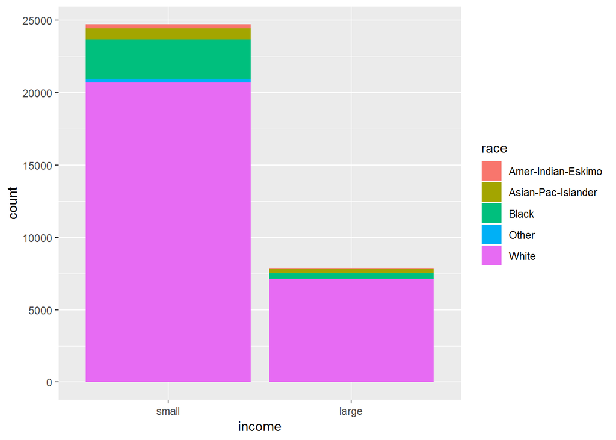

```r
race_income<-adultDf%>%group_by(race,income)%>%summarise(count=n())
ggplot(race_income,aes(x=income,y=count))+geom_bar(stat='identity',aes(fill=race))
```

`Whites have larger proportion in the large income group. Black proportion in the small income group is significant`

*Barplot of income by sex:-*

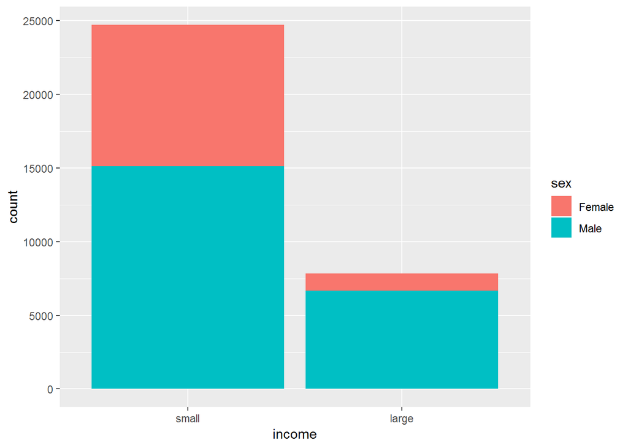

```r
sex_income<-adultDf%>%group_by(sex,income)%>%summarise(count=n())
ggplot(sex_income,aes(x=income,y=count))+geom_bar(stat='identity',aes(fill=sex))
```

`Males have larger proportion in the large income group.`

*Barplot of income by marital-status:-*

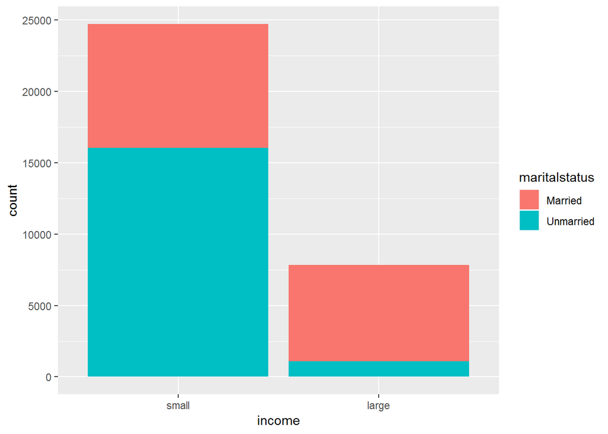

```r
colnames(adultDf)[which(colnames(adultDf) %in% "marital-status")]<-"maritalstatus"
marital_income<-adultDf%>%group_by(maritalstatus,income)%>%summarise(count=n())
ggplot(marital_income,aes(x=income,y=count,fill=maritalstatus))+geom_bar(stat='identity')
```

`Married people have larger proportion in the large income group.`

*Barplot of income by age:-*

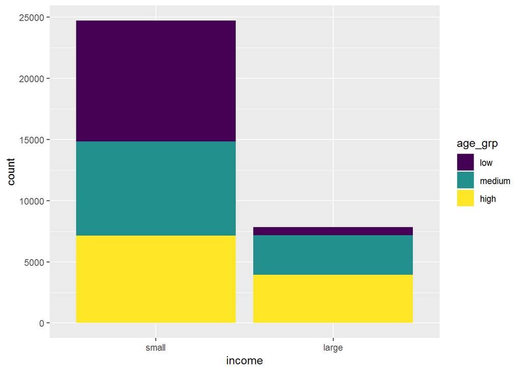

```r
age_income<-adultDf%>%group_by(age_grp,income)%>%summarise(count=n())
ggplot(age_income,aes(x=income,y=count,fill=age_grp))+geom_bar(stat='identity')
```

`age_grp low have a high proportion in the small income group.`

*Barplot of income by hours per week:-*

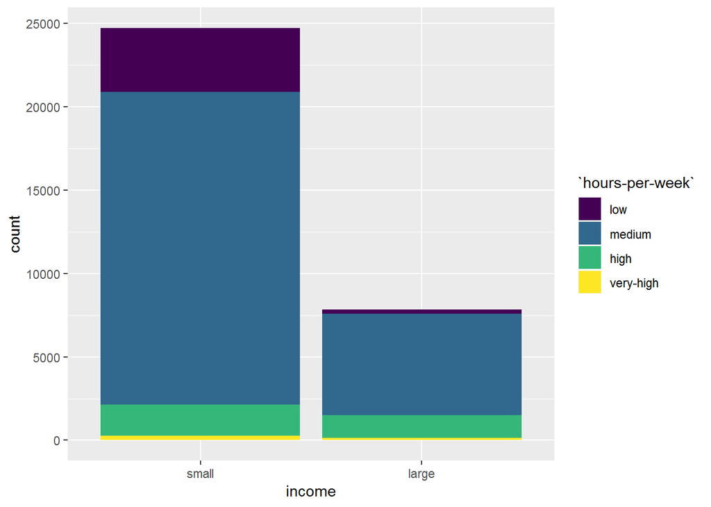

```r
hours_income<-adultDf%>%group_by(`hours-per-week`,income)%>%summarise(count=n())
ggplot(hours_income,aes(x=income,y=count,fill=`hours-per-week`))+geom_bar(stat='identity')
```

*Barplot of income by education:-*

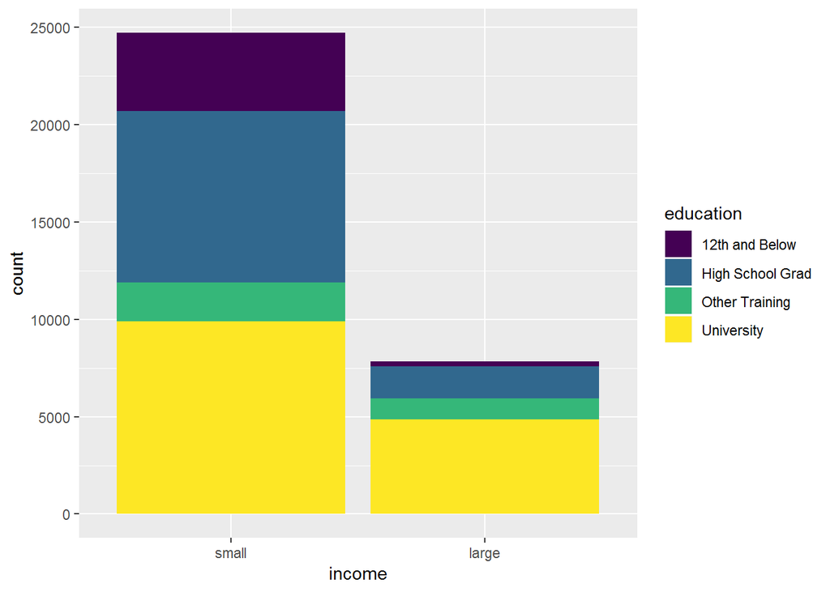

```r
education_income<-adultDf%>%group_by(education,income)%>%summarise(count=n())
ggplot(education_income,aes(x=income,y=count,fill=education))+geom_bar(stat='identity')
```

`People with a university education have a higher proportion in the large income group.`

*Barplot of income by occupation:-*

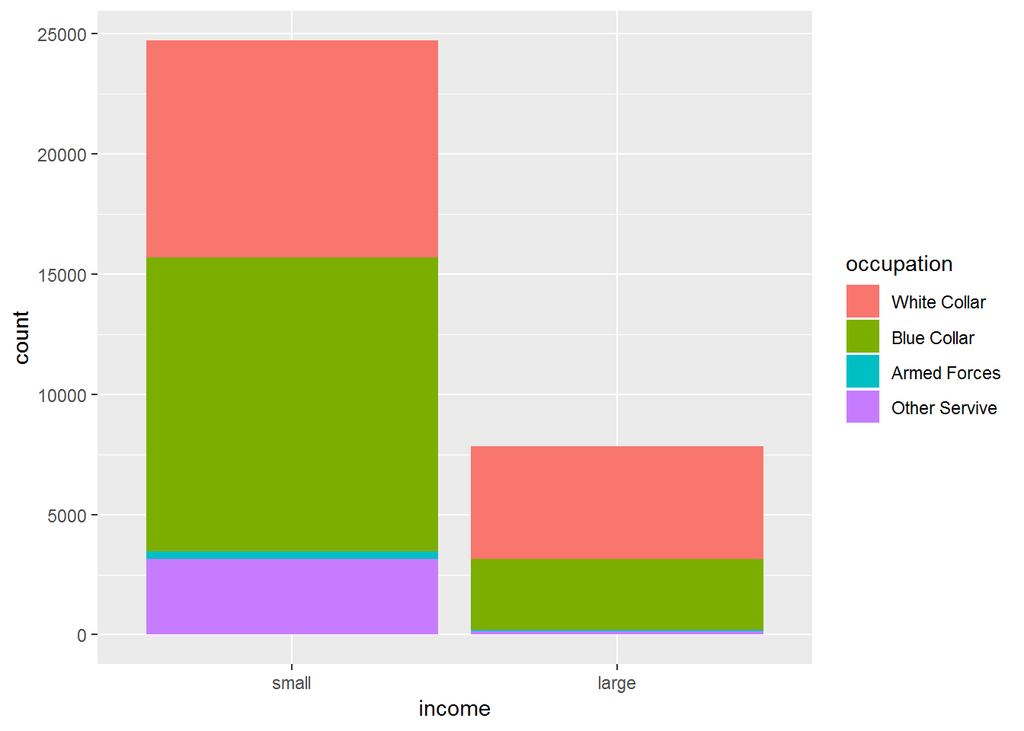

```r
occupation_income<-adultDf%>%group_by(occupation,income)%>%summarise(count=n())
ggplot(occupation_income,aes(x=income,y=count,fill=occupation))+geom_bar(stat='identity')
```

`People with White Collar jobs have higher proportion in the large income group.`

*Barplot of income by relationship:-*

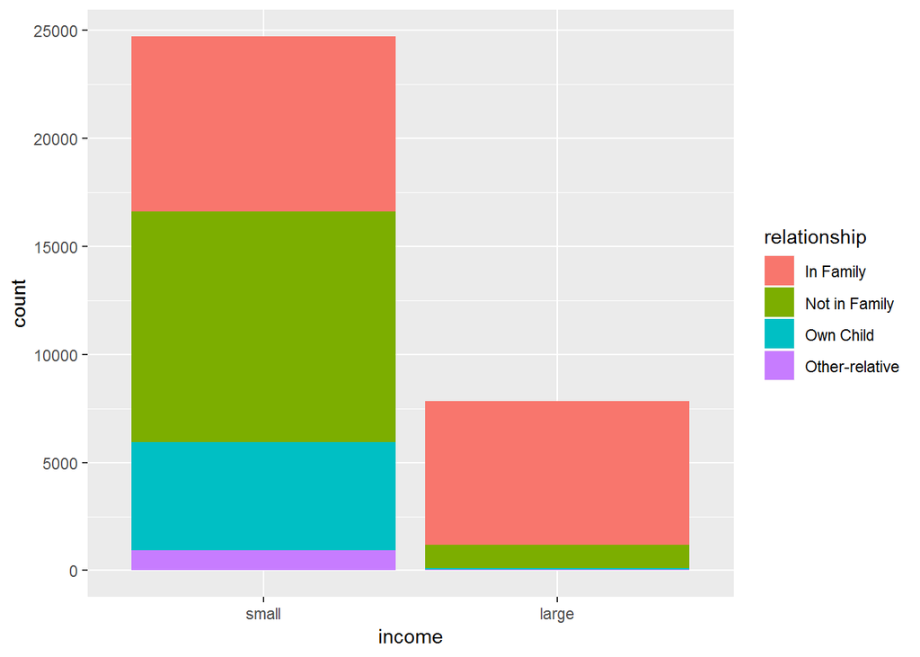

```r
relationship_income<-adultDf%>%group_by(relationship,income)%>%summarise(count=n())
ggplot(relationship_income,aes(x=income,y=count,fill=relationship))+geom_bar(stat='identity')
```

`People with some kind of family relationship have a higher proportion in the large income group.`

*Capital-gain by income:-*

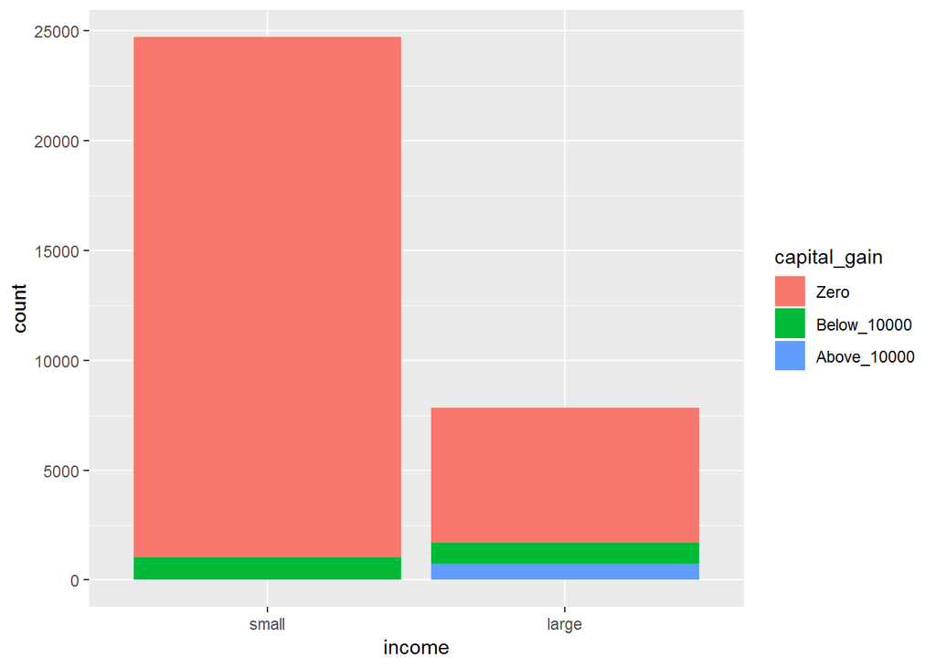

```r
capitalgain_income<-adultDf%>%group_by(capital_gain,income)%>%summarise(count=n())
ggplot(capitalgain_income,aes(x=income,y=count,fill=capital_gain))+geom_bar(stat='identity')
```

`People with capital again above 10000 have a considerable proportion in the large income group and are almost absent from the small income group.`

#### Association Rule Mining:-

**Converting into transactional dataset:-**

```r
fact_var<-sapply(adultDf, is.factor)
adult_trans<-as(adultDf[,fact_var],"transactions")
inspect(head(adult_trans,3))
```

```
##     items                          transactionID
## [1] {workclass=Government,
##      fnlwgt=small,
##      education=University,
##      maritalstatus=Unmarried,
##      occupation=White Collar,
##      relationship=Not in Family,
##      race=White,
##      sex=Male,
##      hours-per-week=medium,
##      native-country=United Stated,
##      income=small,
##      age_grp=medium,
##      capital_gain=Below_10000,
##      capital_loss=Zero}                        1
## [2] {workclass=Self Employed,
##      fnlwgt=small,
##      education=University,
##      maritalstatus=Married,
##      occupation=White Collar,
##      relationship=In Family,
##      race=White,
##      sex=Male,
##      hours-per-week=low,
##      native-country=United Stated,
##      income=small,
##      age_grp=high,
##      capital_gain=Zero,
##      capital_loss=Zero}                        2
## [3] {workclass=Private,
##      fnlwgt=large,
##      education=High School Grad,
##      maritalstatus=Unmarried,
##      occupation=Blue Collar,
##      relationship=Not in Family,
##      race=White,
##      sex=Male,
##      hours-per-week=medium,
##      native-country=United Stated,
##      income=small,
##      age_grp=medium,
##      capital_gain=Zero,
##      capital_loss=Zero}                        3
```

**A function to subset rules and sort them based on decreasing value of lift.This is done to remove redundant rules and get the top rules based on lift:-**

```r
subset_rules<-function(Rules){
  sub_rules <- which(colSums(is.subset(Rules,Rules)) > 1)#Removing redundant rules
  Rules <- sort(Rules[-sub_rules], by = "lift", descreasing = T)
  return(Rules)
}
```

```r
rules<-apriori(adult_trans, parameter = list(support = 0.1, confidence = 0.5, minlen = 3))
```

```
## Apriori
##
## Parameter specification:
##  confidence minval smax arem  aval originalSupport maxtime support minlen
##         0.5    0.1    1 none FALSE            TRUE       5     0.1      3
##  maxlen target   ext
##      10  rules FALSE
##
## Algorithmic control:
##  filter tree heap memopt load sort verbose
##     0.1 TRUE TRUE  FALSE TRUE    2    TRUE
##
## Absolute minimum support count: 3256
##
## set item appearances ...[0 item(s)] done [0.00s].
## set transactions ...[45 item(s), 32561 transaction(s)] done [0.03s].
## sorting and recoding items ... [31 item(s)] done [0.01s].
## creating transaction tree ... done [0.02s].
## checking subsets of size 1 2 3 4 5 6 7 8 9 done [0.19s].
## writing ... [36803 rule(s)] done [0.01s].
## creating S4 object  ... done [0.02s].
```

```r
rules<-subset_rules(rules)
inspect(head(rules, 5))
```

```
##     lhs                             rhs                         support confidence     lift count
## [1] {relationship=Not in Family,
##      age_grp=low}                => {maritalstatus=Unmarried} 0.1115445  0.9792397 1.859836  3632
## [2] {sex=Female,
##      age_grp=low}                => {maritalstatus=Unmarried} 0.1161819  0.8882367 1.686997  3783
## [3] {relationship=Not in Family,
##      age_grp=low}                => {income=small}            0.1099475  0.9652197 1.271380  3580
## [4] {sex=Female,
##      age_grp=low}                => {income=small}            0.1259482  0.9629021 1.268327  4101
## [5] {education=High School Grad,
##      relationship=Not in Family} => {income=small}            0.1130186  0.9610864 1.265936  3680
```

**Plotting rules with default settings:-**

```
## To reduce overplotting, jitter is added! Use jitter = 0 to prevent jitter.
```

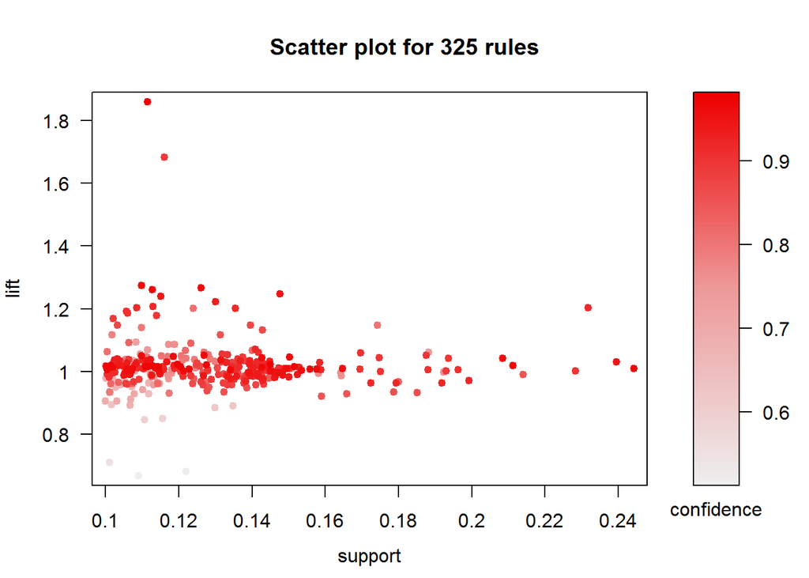

```r
plot(rules, measure = c("support", "lift"), shading = "confidence")
```

**Frequent items:-**

```r
frequent_items <- eclat(adult_trans, parameter = list(support = 0.7, minlen = 2))
```

```
## Eclat
##
## parameter specification:
##  tidLists support minlen maxlen            target   ext
##     FALSE     0.7      2     10 frequent itemsets FALSE
##
## algorithmic control:
##  sparse sort verbose
##       7   -2    TRUE
##
## Absolute minimum support count: 22792
##
## create itemset ...
## set transactions ...[45 item(s), 32561 transaction(s)] done [0.03s].
## sorting and recoding items ... [6 item(s)] done [0.00s].
## creating bit matrix ... [6 row(s), 32561 column(s)] done [0.00s].
## writing  ... [14 set(s)] done [0.00s].
## Creating S4 object  ... done [0.00s].
```

```r
inspect(head(frequent_items,5))
```

```
##     items                            support count
## [1] {income=small,
##      capital_gain=Zero,
##      capital_loss=Zero}            0.7044931 22939
## [2] {income=small,
##      capital_loss=Zero}            0.7362796 23974
## [3] {income=small,
##      capital_gain=Zero}            0.7274039 23685
## [4] {hours-per-week=medium,
##      capital_loss=Zero}            0.7272504 23680
## [5] {race=White,
##      native-country=United Stated,
##      capital_loss=Zero}            0.7477964 24349
```

**Item Frequency Plot:-**

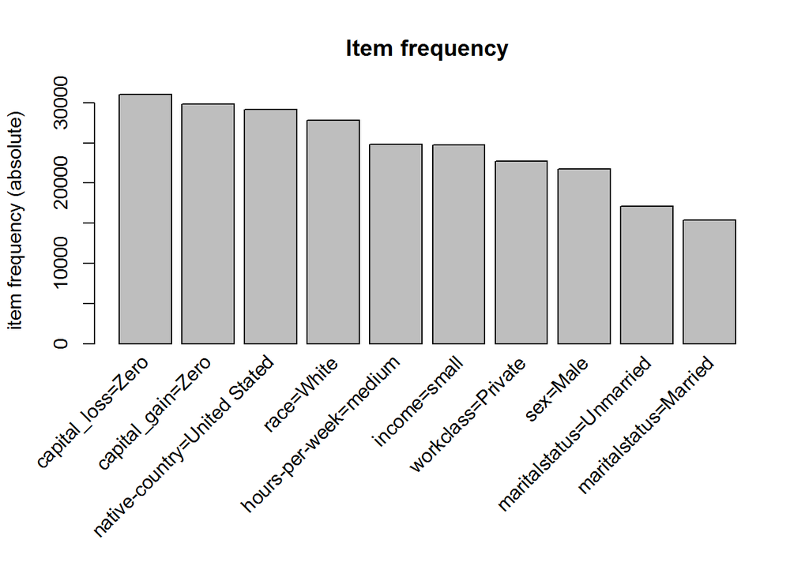

```r
itemFrequencyPlot(adult_trans, topN = 10, type = "absolute", main = "Item frequency")
```

**Rules to predict income:**

*Rules to predict large income :-*

```r
income_large_rules<-apriori(adult_trans,parameter = list(support = 0.01, confidence = 0.3),appearance = list(default="lhs",rhs="income=large"))
```

```
## Apriori
##
## Parameter specification:
##  confidence minval smax arem  aval originalSupport maxtime support minlen
##         0.3    0.1    1 none FALSE            TRUE       5    0.01      1
##  maxlen target   ext
##      10  rules FALSE
##
## Algorithmic control:
##  filter tree heap memopt load sort verbose
##     0.1 TRUE TRUE  FALSE TRUE    2    TRUE
##
## Absolute minimum support count: 325
##
## set item appearances ...[1 item(s)] done [0.00s].
## set transactions ...[45 item(s), 32561 transaction(s)] done [0.03s].
## sorting and recoding items ... [41 item(s)] done [0.01s].
## creating transaction tree ... done [0.02s].
## checking subsets of size 1 2 3 4 5 6 7 8 9 10
```

```
##  done [1.47s].
## writing ... [27372 rule(s)] done [0.03s].
## creating S4 object  ... done [0.03s].
```

```r
income_large_rules<-subset_rules(income_large_rules)
```

*plot of rules with low threshold to visually inspect the region with best rules:-*

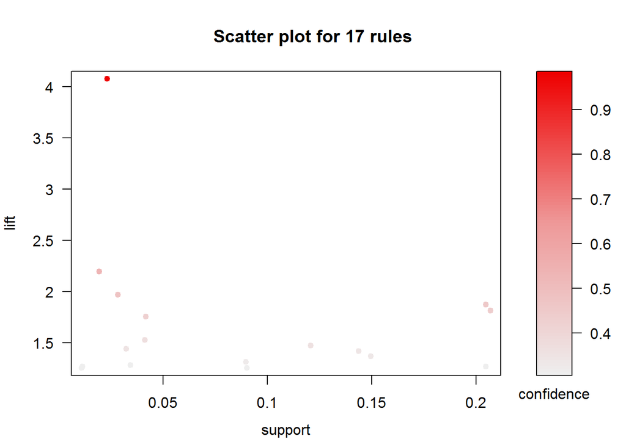

```r
plot(income_large_rules, measure = c("support", "lift"), shading = "confidence")
```

```r
income_large_rules<-apriori(adult_trans,parameter = list(support = 0.02, confidence = 0.4),appearance = list(default="lhs",rhs="income=large"))
```

```
## Apriori
##
## Parameter specification:
##  confidence minval smax arem  aval originalSupport maxtime support minlen
##         0.4    0.1    1 none FALSE            TRUE       5    0.02      1
##  maxlen target   ext
##      10  rules FALSE
##
## Algorithmic control:
##  filter tree heap memopt load sort verbose
##     0.1 TRUE TRUE  FALSE TRUE    2    TRUE
##
## Absolute minimum support count: 651
##
## set item appearances ...[1 item(s)] done [0.00s].
## set transactions ...[45 item(s), 32561 transaction(s)] done [0.03s].
## sorting and recoding items ... [39 item(s)] done [0.01s].
## creating transaction tree ... done [0.02s].
## checking subsets of size 1 2 3 4 5 6 7 8 9 10
```

```
##  done [0.92s].
## writing ... [8565 rule(s)] done [0.01s].
## creating S4 object  ... done [0.01s].
```

```r
income_large_rules<-subset_rules(income_large_rules)
inspect(head(income_large_rules,4))
```

```
##     lhs                           rhs               support confidence     lift count
## [1] {capital_gain=Above_10000} => {income=large} 0.02321796  0.9818182 4.077156   756
## [2] {workclass=Self Employed,
##      occupation=White Collar}  => {income=large} 0.02355579  0.5337509 2.216485   767
## [3] {education=University,
##      age_grp=high}             => {income=large} 0.07358496  0.4933086 2.048543  2396
## [4] {occupation=White Collar,
##      sex=Male}                 => {income=large} 0.11473849  0.4855101 2.016158  3736
```

*Plot of rules that predict large income :-*

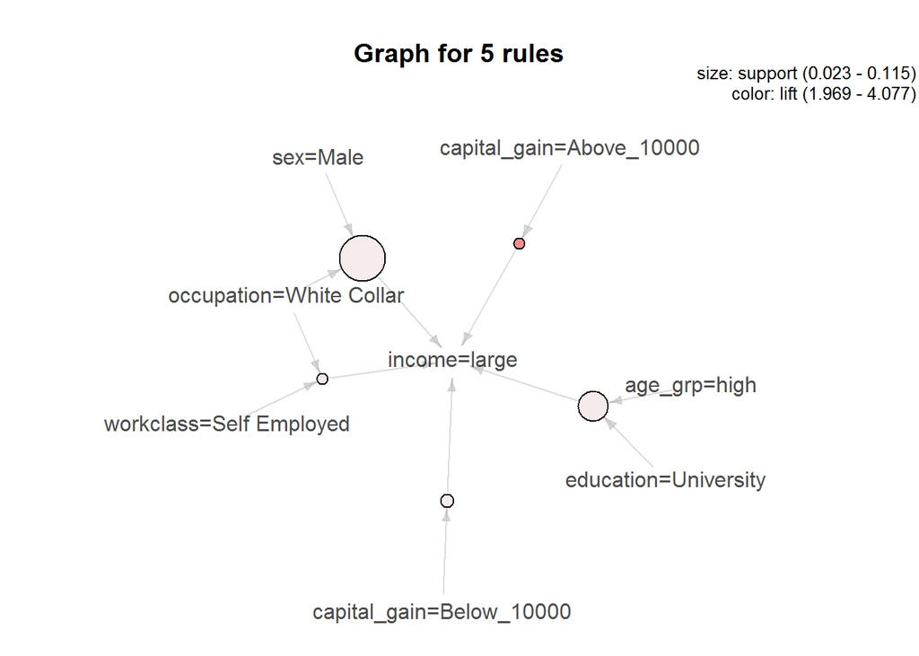

```r
plot(income_large_rules[1:5], method='graph')
```

*Analysis:-*

1.A support of 0.02 and confidence of 0.4 is chosen by analysing the scatterplot of rules.Rules in that region had high support,confidence and lift.

2.{Capital_gain=Abobe_10000} seems like a very good rule to predict income and its intuitive as people with high capital again will tend to have higher income.

3. {workclass=Self Employed,occupation=White Collar} is also an interesting rule as people who with white collar jobs having own businesses have a good chance of being in the large income pool.This rule is consistent with the insight from the barplot.

4.{education=University,age_grp=high} is again an interesting rules as people with a university degree will have higher chance of being in the large income pool and so are people with high age.This rule is consistent with the insight from the barplot.

5.{occupation=White Collar,sex=Male} is also an interesting rule as men are more likely to be in the large income pool due to cultural imbalance and lack of oppurtunity for women. This rule is consistent with the findings from the barplot.

*Rules to predict small income:-*

```r
income_small_rules<-apriori(adult_trans,parameter = list(support = 0.05, confidence = 0.5),appearance = list(default="lhs",rhs="income=small"))
```

```
## Apriori
##
## Parameter specification:
##  confidence minval smax arem  aval originalSupport maxtime support minlen
##         0.5    0.1    1 none FALSE            TRUE       5    0.05      1
##  maxlen target   ext
##      10  rules FALSE
##
## Algorithmic control:
##  filter tree heap memopt load sort verbose
##     0.1 TRUE TRUE  FALSE TRUE    2    TRUE
##
## Absolute minimum support count: 1628
##
## set item appearances ...[1 item(s)] done [0.00s].
## set transactions ...[45 item(s), 32561 transaction(s)] done [0.04s].
## sorting and recoding items ... [35 item(s)] done [0.01s].
## creating transaction tree ... done [0.02s].
## checking subsets of size 1 2 3 4 5 6 7 8 9 10
```

```
##  done [0.42s].
## writing ... [12277 rule(s)] done [0.00s].
## creating S4 object  ... done [0.01s].
```

*plot of rules with low threshold to visually inspect the region with best rules:-*

```
## To reduce overplotting, jitter is added! Use jitter = 0 to prevent jitter.
```

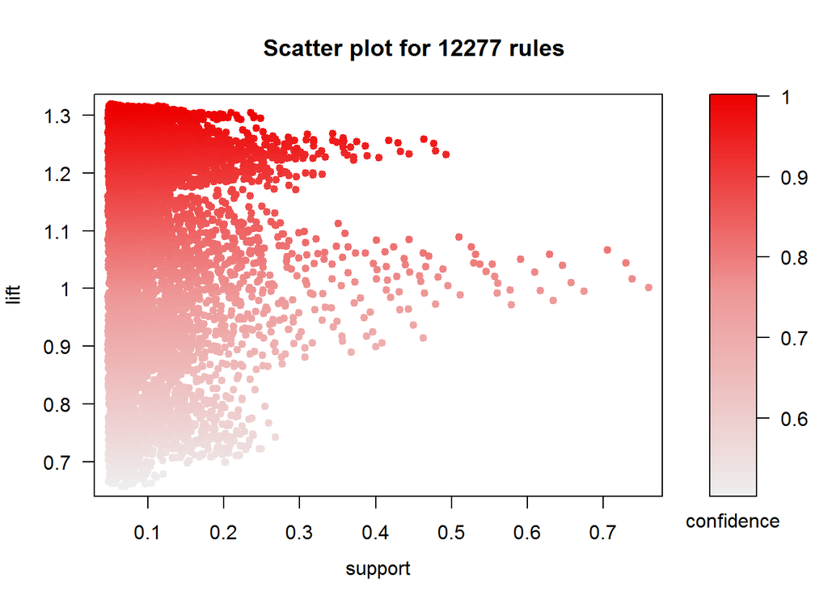

```r
plot(income_small_rules,measure=c("support","lift"),shading="confidence")
```

```r
income_small_rules<-apriori(adult_trans,parameter = list(support = 0.15, confidence = 0.9,maxlen=4),appearance = list(default="lhs",rhs="income=small"))
```

```
## Apriori
##
## Parameter specification:
##  confidence minval smax arem  aval originalSupport maxtime support minlen
##         0.9    0.1    1 none FALSE            TRUE       5    0.15      1
##  maxlen target   ext
##       4  rules FALSE
##
## Algorithmic control:
##  filter tree heap memopt load sort verbose
##     0.1 TRUE TRUE  FALSE TRUE    2    TRUE
##
## Absolute minimum support count: 4884
##
## set item appearances ...[1 item(s)] done [0.00s].
## set transactions ...[45 item(s), 32561 transaction(s)] done [0.03s].
## sorting and recoding items ... [26 item(s)] done [0.01s].
## creating transaction tree ... done [0.02s].
## checking subsets of size 1 2 3 4
```

```
##  done [0.04s].
## writing ... [143 rule(s)] done [0.00s].
## creating S4 object  ... done [0.00s].
```

```r
income_small_rules<-sort(income_small_rules,by = "lift", descreasing = T)
inspect(head(income_small_rules,5))
```

```
##     lhs                          rhs              support confidence     lift count
## [1] {maritalstatus=Unmarried,
##      age_grp=low,
##      capital_gain=Zero}       => {income=small} 0.2414545  0.9878125 1.301139  7862
## [2] {relationship=Own Child,
##      capital_loss=Zero}       => {income=small} 0.1501490  0.9872779 1.300435  4889
## [3] {relationship=Own Child}  => {income=small} 0.1535886  0.9867798 1.299779  5001
## [4] {workclass=Private,
##      maritalstatus=Unmarried,
##      age_grp=low}             => {income=small} 0.1953871  0.9831556 1.295005  6362
## [5] {maritalstatus=Unmarried,
##      age_grp=low,
##      capital_loss=Zero}       => {income=small} 0.2419152  0.9831503 1.294998  7877
```

*Analysis:-*

1.support of 0.15 and confidence of 0.9 chosen by analysing the scatterplot of rules.Rules in that region had high support,confidence and lift.

2.{maritalstatus=Unmarried,age_grp=low,capital_gain=Zero} is an intersting rule as umarried people are less stable in general than married people and tend to have lower incomes.Young people will also have smaller incomes as compared to oler people and zero capital gain indicates no growth. The rule is consistent with the insights derived from the barplot.

3.{relationship=Own Child} is an interesting rule as people with dependents have more responsibilities at home and can be less productive because of that.

4. Marital status looks like an intersting factor that can determine the income.

*A plot of rules with small income:-*

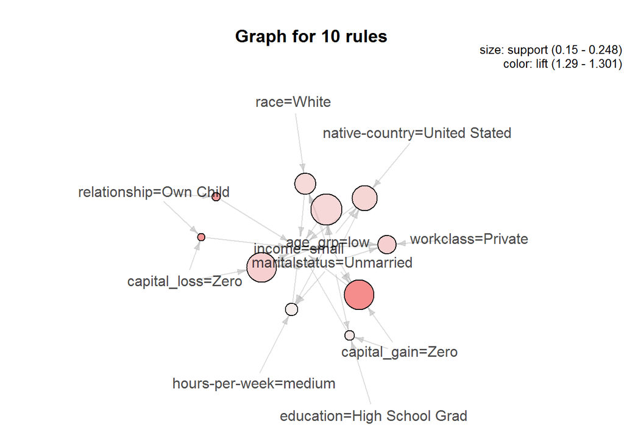

```r
plot(income_small_rules[1:10],method='graph')
```

##### Link to Shiny Application-https://mihird94.shinyapps.io/association_rules_mining/